# 8SVM-下-理论

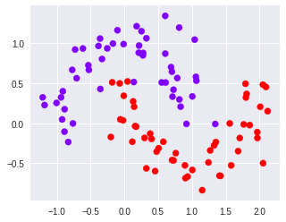

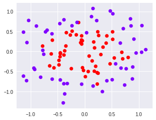

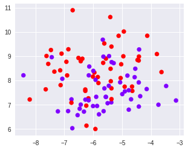

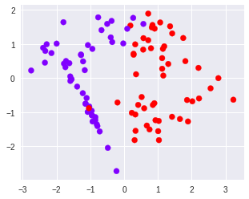

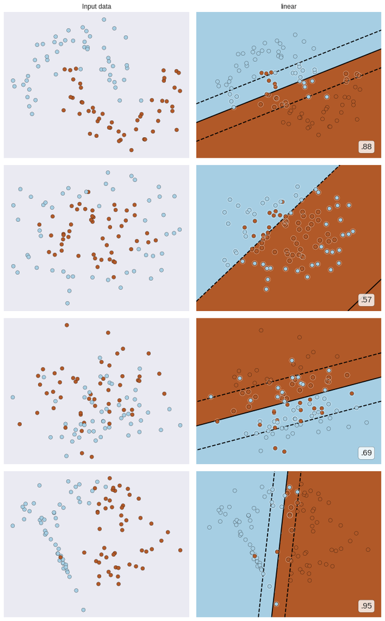

```python
import numpy as np
import matplotlib.pyplot as plt
from matplotlib.colors import ListedColormap
from sklearn import svm
from sklearn.datasets import make_circles, make_moons, make_blobs,make_classification

n_samples = 100

datasets = [
    make_moons(n_samples=n_samples, noise=0.2, random_state=0),
    make_circles(n_samples=n_samples, noise=0.2, factor=0.5, random_state=1),
    make_blobs(n_samples=n_samples, centers=2, random_state=5),
    make_classification(n_samples=n_samples,n_features = 2,n_informative=2,n_redundant=0, random_state=5)
]

Kernel = ["linear"]

#四个数据集分别是什么样子呢？
for X,Y in datasets:
    plt.figure(figsize=(5,4))
    plt.scatter(X[:,0],X[:,1],c=Y,s=50,cmap="rainbow")

nrows=len(datasets)
ncols=len(Kernel) + 1

fig, axes = plt.subplots(nrows, ncols,figsize=(10,16))

#第一层循环：在不同的数据集中循环
for ds_cnt, (X,Y) in enumerate(datasets):

    #在图像中的第一列，放置原数据的分布
    ax = axes[ds_cnt, 0]
    if ds_cnt == 0:
        ax.set_title("Input data")
    ax.scatter(X[:, 0], X[:, 1], c=Y, zorder=10, cmap=plt.cm.Paired,edgecolors='k')
    ax.set_xticks(())
    ax.set_yticks(())

    #第二层循环：在不同的核函数中循环
    #从图像的第二列开始，一个个填充分类结果
    for est_idx, kernel in enumerate(Kernel):

        #定义子图位置
        ax = axes[ds_cnt, est_idx + 1]

        #建模
        clf = svm.SVC(kernel=kernel, gamma=2).fit(X, Y)
        score = clf.score(X, Y)

        #绘制图像本身分布的散点图
        ax.scatter(X[:, 0], X[:, 1], c=Y
                   ,zorder=10
                   ,cmap=plt.cm.Paired,edgecolors='k')
        #绘制支持向量
        ax.scatter(clf.support_vectors_[:, 0], clf.support_vectors_[:, 1], s=100,
                    facecolors='none', zorder=10, edgecolors='white')

        #绘制决策边界
        x_min, x_max = X[:, 0].min() - .5, X[:, 0].max() + .5
        y_min, y_max = X[:, 1].min() - .5, X[:, 1].max() + .5

        #np.mgrid，合并了我们之前使用的np.linspace和np.meshgrid的用法
        #一次性使用最大值和最小值来生成网格
        #表示为[起始值：结束值：步长]
        #如果步长是复数，则其整数部分就是起始值和结束值之间创建的点的数量，并且结束值被包含在内
        XX, YY = np.mgrid[x_min:x_max:200j, y_min:y_max:200j]
        #np.c_，类似于np.vstack的功能
        Z = clf.decision_function(np.c_[XX.ravel(), YY.ravel()]).reshape(XX.shape)
        #填充等高线不同区域的颜色
        ax.pcolormesh(XX, YY, Z > 0, cmap=plt.cm.Paired)
        #绘制等高线
        ax.contour(XX, YY, Z, colors=['k', 'k', 'k'], linestyles=['--', '-', '--'],
                    levels=[-1, 0, 1])

        #设定坐标轴为不显示
        ax.set_xticks(())
        ax.set_yticks(())

        #将标题放在第一行的顶上
        if ds_cnt == 0:
            ax.set_title(kernel)

        #为每张图添加分类的分数
        ax.text(0.95, 0.06, ('%.2f' % score).lstrip('0')
                , size=15
                , bbox=dict(boxstyle='round', alpha=0.8, facecolor='white')
                	#为分数添加一个白色的格子作为底色
                , transform=ax.transAxes #确定文字所对应的坐标轴，就是ax子图的坐标轴本身
                , horizontalalignment='right' #位于坐标轴的什么方向
               )

plt.tight_layout()
plt.show()
```

```python
import numpy as np
import matplotlib.pyplot as plt
from sklearn import svm
from sklearn.datasets import make_blobs
```

```python
class_1 = 500 #类别1有500个样本，10：1
class_2 = 50 #类别2只有50个
centers = [[0.0, 0.0], [2.0, 2.0]] #设定两个类别的中心
clusters_std = [1.5, 0.5] #设定两个类别的方差，通常来说，样本量比较大的类别会更加松散
X, y = make_blobs(n_samples=[class_1, class_2],
                  centers=centers,
                  cluster_std=clusters_std,
                  random_state=0, shuffle=False)
```

```python
X.shape
```

```
(550, 2)
```

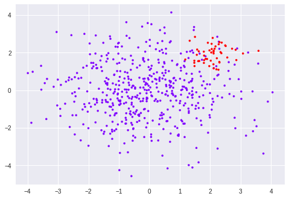

```python
#看看数据集长什么样
plt.scatter(X[:, 0], X[:, 1], c=y, cmap="rainbow",s=10)
plt.show()
#其中红色点是少数类，紫色点是多数类
```

```python
#不设定class_weight
clf = svm.SVC(kernel='linear', C=1.0)
clf.fit(X, y)
```

```
SVC(C=1.0, cache_size=200, class_weight=None, coef0=0.0,
  decision_function_shape='ovr', degree=3, gamma='auto_deprecated',
  kernel='linear', max_iter=-1, probability=False, random_state=None,
  shrinking=True, tol=0.001, verbose=False)
```

```python
#设定class_weight
wclf = svm.SVC(kernel='linear', class_weight={1: 10})
wclf.fit(X, y)
```

```
SVC(C=1.0, cache_size=200, class_weight={1: 10}, coef0=0.0,
  decision_function_shape='ovr', degree=3, gamma='auto_deprecated',
  kernel='linear', max_iter=-1, probability=False, random_state=None,
  shrinking=True, tol=0.001, verbose=False)
```

```python
#给两个模型分别打分看看，这个分数是accuracy准确度
#做样本均衡之后，我们的准确率下降了，没有样本均衡的准确率更高
clf.score(X,y)
```

```
0.9418181818181818
```

```python
wclf.score(X,y)
```

```
0.9127272727272727
```

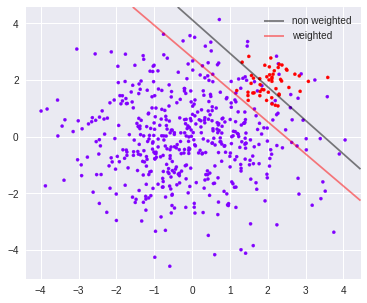

```python
#首先要有数据分布
plt.figure(figsize=(6,5))
plt.scatter(X[:, 0], X[:, 1], c=y, cmap="rainbow",s=10)
ax = plt.gca() #获取当前的子图，如果不存在，则创建新的子图

#绘制决策边界的第一步：要有网格
xlim = ax.get_xlim()
ylim = ax.get_ylim()

xx = np.linspace(xlim[0], xlim[1], 30)
yy = np.linspace(ylim[0], ylim[1], 30)
YY, XX = np.meshgrid(yy, xx)
xy = np.vstack([XX.ravel(), YY.ravel()]).T

#第二步：找出我们的样本点到决策边界的距离
Z_clf = clf.decision_function(xy).reshape(XX.shape)
a = ax.contour(XX, YY, Z_clf, colors='black', levels=[0], alpha=0.5, linestyles=['-'])

Z_wclf = wclf.decision_function(xy).reshape(XX.shape)
b = ax.contour(XX, YY, Z_wclf, colors='red', levels=[0], alpha=0.5, linestyles=['-'])

#第三步：画图例
plt.legend([a.collections[0], b.collections[0]], ["non weighted", "weighted"],
           loc="upper right")
plt.show()
```

```python
a.collections #调用这个等高线对象中画的所有线，返回一个惰性对象
```

```
<a list of 1 mcoll.LineCollection objects>
```

```python
#用[*]把它打开试试看
[*a.collections] #返回了一个linecollection对象，其实就是我们等高线里所有的线的列表
```

[output not shown]

```python
#现在我们只有一条线，所以我们可以使用索引0来锁定这个对象
a.collections[0]
```

[output not shown]

```python
#plt.legend([对象列表],[图例列表],loc)
#只要对象列表和图例列表相对应，就可以显示出图例
```

## 混淆矩阵

在混淆矩阵中，我们将少数类认为是正 例，多数类认为是负例。在决策树，随机森林这些普通的分类算法里，即是说少数类是1，多数类是0。在SVM里， 就是说少数类是1，多数类是-1

### 精确度Precision

```python
y == clf.predict(X)
# 取出被判断正确的样本
```

```
array([ True, False,  True,  True,  True,  True,  True,  True,  True,
        True,  True,  True,  True,  True, False,  True,  True,  True,
        True,  True,  True,  True,  True,  True,  True,  True,  True,
        True,  True,  True,  True,  True,  True,  True,  True,  True,
        True,  True,  True,  True,  True,  True, False,  True,  True,
        True,  True,  True,  True,  True,  True,  True,  True,  True,
       False, False,  True,  True,  True,  True,  True,  True,  True,
        True,  True,  True,  True,  True,  True,  True,  True,  True,
       False,  True,  True,  True,  True,  True,  True,  True,  True,
        True,  True,  True,  True,  True,  True,  True,  True,  True,
        True,  True,  True,  True,  True,  True,  True,  True,  True,
       False,  True,  True,  True,  True,  True,  True,  True,  True,
        True,  True,  True,  True,  True,  True,  True,  True,  True,
        True,  True,  True,  True,  True,  True,  True,  True,  True,
        True,  True,  True,  True,  True,  True,  True,  True,  True,
        True,  True,  True,  True,  True,  True,  True,  True,  True,
        True,  True,  True,  True,  True,  True,  True,  True,  True,
        True,  True,  True,  True,  True,  True,  True,  True,  True,
        True,  True,  True,  True,  True,  True,  True,  True,  True,
        True,  True,  True,  True,  True,  True,  True,  True,  True,
        True,  True,  True,  True,  True,  True,  True,  True,  True,
        True,  True,  True,  True,  True,  True,  True,  True,  True,
        True,  True,  True,  True,  True,  True,  True,  True,  True,
        True,  True, False,  True,  True,  True,  True,  True,  True,
        True,  True,  True,  True,  True,  True,  True,  True,  True,
        True,  True,  True,  True,  True,  True,  True,  True,  True,
        True,  True,  True, False,  True,  True,  True,  True,  True,
        True,  True,  True,  True, False,  True,  True,  True,  True,
        True,  True,  True,  True,  True,  True,  True,  True,  True,
        True,  True,  True,  True,  True,  True,  True,  True,  True,
        True,  True,  True,  True,  True,  True,  True,  True,  True,
        True,  True,  True,  True,  True,  True,  True,  True,  True,
        True,  True,  True,  True,  True,  True,  True,  True,  True,
        True,  True,  True,  True,  True,  True,  True,  True,  True,
        True,  True,  True,  True,  True,  True,  True,  True,  True,
        True,  True,  True,  True,  True,  True,  True,  True,  True,
        True,  True,  True,  True,  True,  True,  True,  True,  True,
        True,  True,  True,  True,  True,  True,  True,  True,  True,
        True,  True,  True,  True,  True,  True,  True,  True,  True,
        True,  True,  True,  True,  True,  True,  True,  True,  True,
        True,  True,  True,  True,  True,  True,  True,  True,  True,
        True,  True,  True,  True,  True,  True,  True,  True,  True,
        True,  True,  True,  True,  True,  True,  True,  True,  True,
        True,  True,  True,  True,  True,  True,  True,  True,  True,
        True,  True,  True,  True,  True,  True,  True,  True,  True,
        True,  True,  True,  True,  True,  True,  True,  True,  True,
        True,  True,  True,  True,  True,  True,  True, False,  True,
        True,  True,  True,  True,  True,  True,  True,  True,  True,
        True,  True,  True,  True,  True,  True,  True,  True,  True,
        True,  True,  True,  True,  True,  True,  True,  True,  True,
        True,  True,  True,  True,  True,  True,  True,  True,  True,
        True,  True,  True,  True,  True,  True,  True,  True,  True,
        True,  True,  True, False,  True,  True,  True,  True,  True,
        True,  True,  True,  True,  True,  True,  True,  True,  True,
        True,  True,  True,  True,  True,  True,  True,  True,  True,
        True,  True,  True,  True,  True,  True,  True,  True, False,
        True,  True,  True, False, False,  True,  True, False,  True,
       False,  True, False, False,  True,  True, False,  True,  True,
        True,  True, False, False,  True,  True,  True, False, False,
        True,  True,  True,  True, False, False,  True,  True, False,
       False,  True, False, False,  True, False, False,  True,  True,
        True])
```

```python
(y[y == clf.predict(X)] == 1).sum()
```

```
30
```

```python
#所有判断正确并确实为1的样本 / 所有被判断为1的样本
#对于没有class_weight，没有做样本平衡的灰色决策边界来说：
(y[y == clf.predict(X)] == 1).sum()/(clf.predict(X) == 1).sum()
```

```
0.7142857142857143
```

```python
(y[y == clf.predict(X)] == 1).sum() #True = 1, False =1 #真实值等于预测值的全部点
```

```
30
```

```python
int(False)
```

```
0
```

```python
#对于有class_weight，做了样本平衡的红色决策边界来说：
(y[y == wclf.predict(X)] == 1).sum()/(wclf.predict(X) == 1).sum()
```

```
0.5102040816326531
```

### 召回率Recall

```python
#所有predict为1的点 / 全部为1的点的比例
#对于没有class_weight，没有做样本平衡的灰色决策边界来说：
(y[y == clf.predict(X)] == 1).sum()/(y == 1).sum()
```

```
0.6
```

```python
#对于有class_weight，做了样本平衡的红色决策边界来说：
(y[y == wclf.predict(X)] == 1).sum()/(y == 1).sum()
```

```
1.0
```

### 判错多数类的考量：特异度与假正率

#### 特异度(Specificity)

表示所有真实为0的样本中，被正确预测为0的样本所占的比例。在支持向量机中，可以形象地 表示为，决策边界下方的点占所有紫色点的比例

```python
#所有被正确预测为0的样本 / 所有的0样本
#对于没有class_weight，没有做样本平衡的灰色决策边界来说：
(y[y == clf.predict(X)] == 0).sum()/(y == 0).sum()
```

```
0.976
```

```python
#对于有class_weight，做了样本平衡的红色决策边界来说：
(y[y == wclf.predict(X)] == 0).sum()/(y == 0).sum()
```

```
0.904
```

# ROC曲线以及其相关问题

衡量模型在尽量捕捉少数类的时候，误伤多数类的情况如何变化

ROC曲线，全称The Receiver Operating Characteristic Curve，译为受试者操作特性曲线。这是一条以不同阈值 下的假正率FPR为横坐标，不同阈值下的召回率Recall为纵坐标的曲线

## 1 概率(probability)与阈值(threshold)

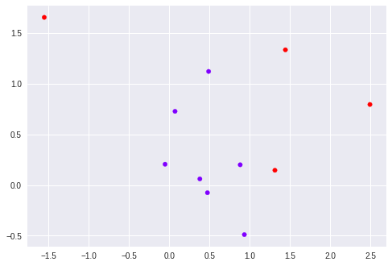

```python
class_1_ = 7
class_2_ = 4
centers_ = [[0.0, 0.0], [1,1]]
clusters_std = [0.5, 1]
X_, y_ = make_blobs(n_samples=[class_1_, class_2_],
                  centers=centers_,
                  cluster_std=clusters_std,
                  random_state=0, shuffle=False)
plt.scatter(X_[:, 0], X_[:, 1], c=y_, cmap="rainbow",s=30)
plt.show()
```

```python
y_
```

```
array([0, 0, 0, 0, 0, 0, 0, 1, 1, 1, 1])
```

```python
from sklearn.linear_model import LogisticRegression as LogiR
```

```python
clf_lo = LogiR().fit(X_,y_)
```

```python
prob = clf_lo.predict_proba(X_)
```

```python
prob
```

```
array([[0.60466356, 0.39533644],
       [0.45891589, 0.54108411],
       [0.71798647, 0.28201353],
       [0.67910911, 0.32089089],
       [0.66473898, 0.33526102],
       [0.56277457, 0.43722543],
       [0.66205409, 0.33794591],
       [0.35516738, 0.64483262],
       [0.38160618, 0.61839382],
       [0.58528378, 0.41471622],
       [0.50149311, 0.49850689]])
```

```python
#将样本和概率放到一个DataFrame中
import pandas as pd
prob = pd.DataFrame(prob)
```

```python
prob.columns = ["zero","one"]
```

```python
prob
```

|  | zero | one |
| --- | --- | --- |
| 0 | 0.604664 | 0.395336 |
| 1 | 0.458916 | 0.541084 |
| 2 | 0.717986 | 0.282014 |
| 3 | 0.679109 | 0.320891 |
| 4 | 0.664739 | 0.335261 |
| 5 | 0.562775 | 0.437225 |
| 6 | 0.662054 | 0.337946 |
| 7 | 0.355167 | 0.644833 |
| 8 | 0.381606 | 0.618394 |
| 9 | 0.585284 | 0.414716 |
| 10 | 0.501493 | 0.498507 |

```python
#手动调节阈值，来改变我们的模型效果
for i in range(prob.shape[0]):
    if prob.loc[i,"one"] > 0.5:
        prob.loc[i,"pred"] = 1
    else:
        prob.loc[i,"pred"] = 0
```

```python
prob["y_true"] = y_
```

```python
prob
```

|  | zero | one | pred | y_true |
| --- | --- | --- | --- | --- |
| 0 | 0.604664 | 0.395336 | 0.0 | 0 |
| 1 | 0.458916 | 0.541084 | 1.0 | 0 |
| 2 | 0.717986 | 0.282014 | 0.0 | 0 |
| 3 | 0.679109 | 0.320891 | 0.0 | 0 |
| 4 | 0.664739 | 0.335261 | 0.0 | 0 |
| 5 | 0.562775 | 0.437225 | 0.0 | 0 |
| 6 | 0.662054 | 0.337946 | 0.0 | 0 |
| 7 | 0.355167 | 0.644833 | 1.0 | 1 |
| 8 | 0.381606 | 0.618394 | 1.0 | 1 |
| 9 | 0.585284 | 0.414716 | 0.0 | 1 |
| 10 | 0.501493 | 0.498507 | 0.0 | 1 |

```python
prob = prob.sort_values(by="one",ascending=False)
# 排序
```

```python
prob
```

|  | zero | one | pred | y_true |
| --- | --- | --- | --- | --- |
| 7 | 0.355167 | 0.644833 | 1.0 | 1 |
| 8 | 0.381606 | 0.618394 | 1.0 | 1 |
| 1 | 0.458916 | 0.541084 | 1.0 | 0 |
| 10 | 0.501493 | 0.498507 | 0.0 | 1 |
| 5 | 0.562775 | 0.437225 | 0.0 | 0 |
| 9 | 0.585284 | 0.414716 | 0.0 | 1 |
| 0 | 0.604664 | 0.395336 | 0.0 | 0 |
| 6 | 0.662054 | 0.337946 | 0.0 | 0 |
| 4 | 0.664739 | 0.335261 | 0.0 | 0 |
| 3 | 0.679109 | 0.320891 | 0.0 | 0 |
| 2 | 0.717986 | 0.282014 | 0.0 | 0 |

```python
from sklearn.metrics import confusion_matrix as CM, precision_score as P, recall_score as R
```

```python
CM(prob.loc[:,"y_true"],prob.loc[:,"pred"],labels=[1,0])
# 少数类写在前面
```

```
array([[2, 2],
       [1, 6]])
```

```python
#试试看手动计算Precision和Recall?
```

```python
2/3
```

```
0.6666666666666666
```

```python
2/4
```

```
0.5
```

```python
P(prob.loc[:,"y_true"],prob.loc[:,"pred"],labels=[1,0])
```

```
0.6666666666666666
```

```python
R(prob.loc[:,"y_true"],prob.loc[:,"pred"],labels=[1,0])
```

```
0.5
```

```python
prob
```

|  | zero | one | pred | y_true |
| --- | --- | --- | --- | --- |
| 7 | 0.355167 | 0.644833 | 1.0 | 1 |
| 8 | 0.381606 | 0.618394 | 1.0 | 1 |
| 1 | 0.458916 | 0.541084 | 1.0 | 0 |
| 10 | 0.501493 | 0.498507 | 0.0 | 1 |
| 5 | 0.562775 | 0.437225 | 0.0 | 0 |
| 9 | 0.585284 | 0.414716 | 0.0 | 1 |
| 0 | 0.604664 | 0.395336 | 0.0 | 0 |
| 6 | 0.662054 | 0.337946 | 0.0 | 0 |
| 4 | 0.664739 | 0.335261 | 0.0 | 0 |
| 3 | 0.679109 | 0.320891 | 0.0 | 0 |
| 2 | 0.717986 | 0.282014 | 0.0 | 0 |

```python
for i in range(prob.shape[0]):
    if prob.loc[i,"one"] > 0.4:
        prob.loc[i,"pred"] = 1
    else:
        prob.loc[i,"pred"] = 0
```

```python
prob
```

|  | zero | one | pred | y_true |
| --- | --- | --- | --- | --- |
| 7 | 0.355167 | 0.644833 | 1.0 | 1 |
| 8 | 0.381606 | 0.618394 | 1.0 | 1 |
| 1 | 0.458916 | 0.541084 | 1.0 | 0 |
| 10 | 0.501493 | 0.498507 | 1.0 | 1 |
| 5 | 0.562775 | 0.437225 | 1.0 | 0 |
| 9 | 0.585284 | 0.414716 | 1.0 | 1 |
| 0 | 0.604664 | 0.395336 | 0.0 | 0 |
| 6 | 0.662054 | 0.337946 | 0.0 | 0 |
| 4 | 0.664739 | 0.335261 | 0.0 | 0 |
| 3 | 0.679109 | 0.320891 | 0.0 | 0 |
| 2 | 0.717986 | 0.282014 | 0.0 | 0 |

```python
CM(prob.loc[:,"y_true"],prob.loc[:,"pred"],labels=[1,0])
```

```
array([[4, 0],
       [2, 5]])
```

```python
P(prob.loc[:,"y_true"],prob.loc[:,"pred"],labels=[1,0])
```

```
0.6666666666666666
```

```python
R(prob.loc[:,"y_true"],prob.loc[:,"pred"],labels=[1,0])
```

```
1.0
```

```python
#注意，降低或者升高阈值并不一定能够让模型的效果变好，一切都基于我们要追求怎样的模型效果
#通常来说，降低阈值能够升高Recall
```

## 2SVM实现概率预测：重要参数probability

```python
#使用最初的X和y，样本不均衡的这个模型

class_1 = 500 #类别1有500个样本
class_2 = 50 #类别2只有50个
centers = [[0.0, 0.0], [2.0, 2.0]] #设定两个类别的中心
clusters_std = [1.5, 0.5] #设定两个类别的方差，通常来说，样本量比较大的类别会更加松散
X, y = make_blobs(n_samples=[class_1, class_2],
                  centers=centers,
                  cluster_std=clusters_std,
                  random_state=0, shuffle=False)
```

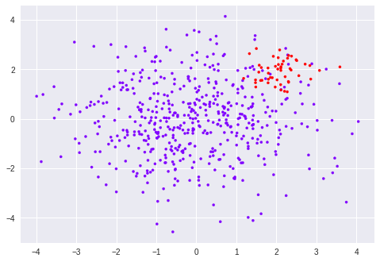

```python
#看看数据集长什么样
plt.scatter(X[:, 0], X[:, 1], c=y, cmap="rainbow",s=10)
#其中红色点是少数类，紫色点是多数类
```

```python
clf_proba = svm.SVC(kernel="linear",C=1.0,probability=True).fit(X,y)
```

```python
clf_proba.predict_proba(X).shape #生成的各类标签下的概率
```

```
(550, 2)
```

```python
clf_proba.predict_proba(X)
```

```
array([[0.69403782, 0.30596218],
       [0.27295806, 0.72704194],
       [0.96329341, 0.03670659],
       ...,
       [0.16311967, 0.83688033],
       [0.36441388, 0.63558612],
       [0.32627979, 0.67372021]])
```

```python
clf_proba.decision_function(X)
```

```
array([ -0.39182241,   0.95617053,  -2.24996184,  -2.63659269,
        -3.65243197,  -1.67311996,  -2.56396417,  -2.80650393,
        -1.76184723,  -4.7948575 ,  -7.59061196,  -3.66174848,
        -2.2508023 ,  -4.27626526,   0.78571364,  -3.24751892,
        -8.57016271,  -4.45823747,  -0.14034183,  -5.20657114,
        -8.02181046,  -4.18420871,  -5.6222409 ,  -5.12602771,
        -7.22592707,  -5.07749638,  -6.72386021,  -3.4945225 ,
        -3.51475144,  -5.72941551,  -5.79160724,  -8.06232013,
        -4.36303857,  -6.25419679,  -5.59426696,  -2.60919281,
        -3.90887478,  -4.38754704,  -6.46432224,  -4.54279979,
        -4.78961735,  -5.53727469,   1.33920817,  -2.27766451,
        -4.39650854,  -2.97649872,  -2.26771979,  -2.40781748,
        -1.41638181,  -3.26142275,  -2.7712218 ,  -4.87288439,
        -3.2594128 ,  -5.91189118,   1.48676267,   0.5389064 ,
        -2.76188843,  -3.36126945,  -2.64697843,  -1.63635284,
        -5.04695135,  -1.59196902,  -5.5195418 ,  -2.10439349,
        -2.29646147,  -4.63162339,  -5.21532213,  -4.19325629,
        -3.37620335,  -5.0032094 ,  -6.04506666,  -2.84656859,
         1.5004014 ,  -4.02677739,  -7.07160609,  -1.66193239,
        -6.60981996,  -5.23458676,  -3.70189918,  -6.74089425,
        -2.09584948,  -2.28398296,  -4.97899921,  -8.12174085,
        -1.52566274,  -1.99176286,  -3.54013094,  -4.8845886 ,
        -6.51002015,  -4.8526957 ,  -6.73649174,  -8.50103589,
        -5.35477446,  -5.93972132,  -3.09197136,  -5.95218482,
        -5.87802088,  -3.41531761,  -1.50581423,   1.69513218,
        -5.08155767,  -1.17971205,  -5.3506946 ,  -5.21493342,
        -3.73358514,  -2.01273566,  -3.39045625,  -6.34357458,
        -3.54776648,  -0.17804673,  -6.26887557,  -4.17973771,
        -6.68896346,  -3.46095619,  -5.47965411,  -7.30835247,
        -4.41569899,  -4.95103272,  -4.52261342,  -2.32912228,
        -5.78601433,  -4.75347157,  -7.10337939,  -0.4589064 ,
        -7.67789856,  -4.01780827,  -4.3031773 ,  -1.83727693,
        -7.40091653,  -5.95271547,  -6.91568411,  -5.20341905,
        -7.19695832,  -3.02927263,  -4.48056922,  -7.48496425,
        -0.07011269,  -5.80292499,  -3.38503533,  -4.58498843,
        -2.76260661,  -3.01843998,  -2.67539002,  -4.1197355 ,
        -0.94129257,  -5.89363772,  -1.6069038 ,  -2.6343464 ,
        -3.04465464,  -4.23219535,  -3.91622593,  -5.29389964,
        -3.59245628,  -8.41452726,  -3.09845691,  -2.71798914,
        -7.1383473 ,  -4.61490324,  -4.57817871,  -4.34638288,
```

[output cut: 83 more lines]

```
        -5.08348781,  -3.71891247,  -2.09779606,  -3.04082162,
        -5.12536015,  -2.96071945,  -4.28796395,  -6.6231135 ,
         1.00003406,   0.03907036,   0.46718521,  -0.3467975 ,
         0.32350521,   0.47563771,   1.10055427,  -0.67580418,
        -0.46310299,   0.40806733,   1.17438632,  -0.55152081,
         0.84476439,  -0.91257798,   0.63165546,  -0.13845693,
        -0.22137683,   1.20116183,   1.18915628,  -0.40676459,
         1.35964325,   1.14038015,   1.27914468,   0.19329823,
        -0.16790648,  -0.62775078,   0.66095617,   2.18236076,
         0.07018415,  -0.26762451,  -0.25529448,   0.32084111,
         0.48016592,   0.28189794,   0.60568093,  -1.07472716,
        -0.5088941 ,   0.74892526,   0.07203056,  -0.10668727,
        -0.15662946,   0.09611498,  -0.39521586,  -0.79874442,
         0.65613691,  -0.39386485,  -1.08601917,   1.44693858,
         0.62992794,   0.76536897])
```

```python
clf_proba.decision_function(X).shape
```

```
(550,)
```